# tme-01

## IA & Data science (LU3IN0226) -- 2025-2026

*© Equipe pédagogique: Christophe Marsala, Olivier Schwander, Jean-Noël Vittaut, Maxellende Julienne.*

**[Q]** **Indiquer dans la boîte ci-dessous vos noms et prénoms :**

**[Q]** **Renommer ce notebook**

Tout en haut de cette page, cliquer sur `tme-01` et rajouter à la suite de `tme-01` les noms des membres du binômes séparés par un tiret.

Par exemple, pour le binôme Luke Skywalker et Han Solo, le nom de fichier devient :

```
tme-01-Skywalker-Solo
```

Penser à sauvegarder fréquemment le fichier en cours de travail :

- soit en cliquant sur l'icône "disquette"
- soit par la combinaison de touches [Ctrl]-S

IMPORTANT: soumission de votre fichier final

**Nom à donner au fichier à poster** : *tme-01-Nom1-Nom2.ipynb*

- *Nom1* et *Nom2* : noms des membres du binôme
- ne pas compresser ou faire une archive: il faut rendre le notebook tel quel, éventuellement, si vous avez d'autres fichiers vous les rendez séparément.

**Echancier pour la soumission de votre compte-rendu:**

- le compte-rendu d'une séance doit être remis obligatoirement avant le début de la séance suivante.

**Le compte-rendu est soumis sur la page Moodle.**

## Semaine 1: structures de données

## Présentation

### Objectifs de ce TME 1

Le travail à réaliser est le suivant :

- apprendre à utiliser jupyter notebook.
- se documenter sur les structures de données qui seront utilisées pour programmer tout au long du semestre: numpy et pandas.
- implémenter des premières fonctions qui seront utiles ce semestre.

## Apprendre à utiliser jupyter notebook

Ce document est dynamique: il est composé de "boîtes" qui peuvent être "compilées" par la commande "Run Cells" du menu "Cell" (ou bien en cliquant sur l'icône >| ou par la combinaison des touches [SHIFT][ENTREE]).

Il y a **2 types principaux** de boîtes :

- les boîtes "Markdown": tout ce qui est tapé dans ces boîtes est du texte qui sera rendu "joliment" après avoir été compilé. On peut y écrire des commandes en Latex pour définir des équations, et il reconnaît certaines balises HTML. En cliquant 2 fois dans une boîte Markdown compilée, on a accès à son contenu et on peut alors le modifier.
- les boîtes "Code": dans ces boîtes, on écrit du code Python. La compilation de la boîte produit l'exécution de ce code Python et produit une boîte "Out" dans laquelle le résultat de la dernière commande est affiché. On peut y écrire tout code Python valide. Ce type de boîtes se reconnaît par "In [n]" inscrit à côté de leur coin haut gauche ("n" est un entier).

Le type d'une boîte peut être modifié à l'aide du menu en haut de la page (juste au dessus du texte).

L'icône "+" permet de créer une nouvelle boîte juste en dessous de la boîte active.

L'icône avec les ciseaux permet d'effacer la boîte active (attention ! c'est **irréversible !**).

Pour en savoir plus :

- https://docs.jupyter.org/en/latest/

Vous pouvez aussi vous référer à la documentation Python:

- https://www.python.org/

Dans ce qui suit, les boîtes Markdown commençant par **[Q]** posent des questions auxquelles il faut répondre dans la boîte qui suit directement (éventuellement, en créant des nouvelles boîtes de type "Code" ou "Markdown", à votre convenance). Certaines des boîtes "Code" à remplir sont suivies d'une sortie "Out[.]:" qui montre un exemple de résultat attendu.

N'hésitez pas à créer de nouvelles boîtes "Code" ou "Markdown" dans ce document si vous en avez besoin (cela est même conseillé !).

```python
# exemple de boîte de code :
#    --> sélectionner cette boîte (en cliquant à l'intérieur)
#    --> effectuer "Run Cells" du Menu "Cell" (ou bien cliquer sur l'icône >|)
#

print("Un essai quelconque :")
2+3
```

On peut, par exemple, vérifier la version de l'interpréteur Python utilisé dans ce notebook:

```python
# - - - - - - - - - - - - - - - - - -
# imports utiles
import math
import time
import sys
# - - - - - - - - - - - - - - - - - -
# Information sur l'environnent utilisé ici:
print("Version python:")
print("\tPython ",sys.version)
```

**Remarque:** votre version de l'interpréteur Python doit être supérieure ou égale à $3.8$.

**[Q]** Dans la boîte "Code" suivante, donner les instructions Python pour effectuer le calcul : $$-\frac{1}{3}\log_2(\frac{1}{3})-\frac{2}{3}\log_2(\frac{2}{3})$$

Dont la valeur à trouver est : 0.9182958340544896

Important : en lisant le texte d'un fichier jupyter sur votre ordinateur, pensez bien à exécuter les boîtes "Code" dans l'ordre de leur apparition. Toute la page se comporte comme une session Python unique et il pour exécuter certaines boîtes il est nécessaire que les précédentes aient été exécutées au préalable.

De même, vous pouvez réinitialiser complètement la session en cliquant sur Noyau et redémarrer.

**[Q]** Dans la boîte "Code" suivante, écrire la fonction `calcul` qui, étant donné un réel $x$ de [0,1] rend la valeur du calcul $$-x\log_2(x)-(1-x)\log_2(1-x)$$ si $x\not= 0$ et $x \not= 1$ ou la valeur $0.0$ sinon.

```python
calcul(0)
```

```
0.0
```

```python
calcul(1/3)
```

```
0.9182958340544896
```

```python
calcul(0.5)
```

```
1.0
```

## Documentation

Dans un premier temps, et c'est un des objectifs de cette séance, vous devez prendre en main les libraries **numpy**, **pandas** et **matplotlib**:

- Numpy = http://scipy.github.io/old-wiki/pages/Tentative_NumPy_Tutorial ou bien https://realpython.com/numpy-tutorial/
- Pandas = http://pandas.pydata.org/pandas-docs/stable/10min.html
- Matplotlib = https://matplotlib.org/stable/index.html

Lisez ces pages et pratiquez ces tutoriaux afin de bien vous familiariser avec ces outils.

Pour utiliser les 3 librairies précédentes, il est nécessaire qu'elles existent dans votre environnement. Pour vérifier, utiliser la commande suivante qui donne l'ensemble des librairies installées:

```
    pip list
```

Si une librairie n'est pas installée, une erreur peut se produire lors de son import. Il est alors nécessaire de l'installer. Par exemple, pour la librairie pandas sur les machines de la PPTI:

- dans un terminal, exécuter la commande:

  ```
    pip install --user -U --proxy http://proxy:3128 pandas
  ```

(le proxy n'est nécessaire que pour les salles machines, vous n'avez pas à l'utiliser sur vos machines personnelles).

- une fois la librairie installée, il est nécessaire de relancer le noyau Python de Jupyter: dans le menu de Jupyter tout en haut de la page, choisir "`Kernel -> restart`"

**[Q]** Donner dans la boîte suivante les grandes caractéristiques de chacunes de ces 3 librairies: A quoi servent-elles ? Que permettent-elles de représenter ? Quelle est leur utilité et leurs spécificités ? etc. etc.

Donner des exemples de leurs utilisations spécifiques.

```python
# - - - - - - - - - - - - - - - - - -
# Importation des librairies utiles dans nos séances:
import numpy as np
import pandas as pd
import matplotlib.pyplot as plt
import matplotlib as mtpl
%matplotlib inline
```

```python
# - - - - - - - - - - - - - - - - - -
# Information sur la version des librairies:
print("\tpandas: ",pd.__version__)
print("\tnumpy: ",np.__version__)
print("\tmatplotlib: ",mtpl.__version__)
```

**[Q]** Pour vous habituer à utiliser la librairie numpy, reprenez ici les questions 6 à 9 de l'exercice 1 da la feuille de TD 1.

**[Q]** On souhaite tracer la courbe associée à la fonction `calcul` précédente pour $x\in[0,1]$. On commence d'abord par calculer des valeurs de la fonction pour plusieurs $x$ puis on trace la courbe avec la fonction `plot` de la librairie matplotlib (cf. la doc).

[figure not shown]

```python
# Compléter les instructions suivantes:

#valeurs_x =   #A COMPLETER#  # liste qui contient 21 valeurs de 0.0 à 1.0 espacées de 1/20. (ie. 0.0, 0.0+1/20, etc.)
#res_calcul =   #A COMPLETER#  # liste qui contient la valeur de la fonction calcul pour chaque x contenu dans la valeur

# Tracer de la courbe des variations
plt.plot( #A COMPLETER# )

#A COMPLETER#
# -> indiquer comme label de l'axe des x : "x"
# -> indiquer comme label de l'axe des y: "calcul(x)"
# -----------------------------------------------

plt.show()
```

## Programmation et expérimentation

Le jeu de données (ou *dataset*) qui sera utilisé dans cette séance pour valider vos fonctions correspond à des données concernant des prix dans différents états d'Amérique du Nord.

La référence de ce dataset est disponible ici : https://github.com/amitkaps/weed/blob/master/1-Acquire.ipynb

Ces données sont aussi fournies dans le fichier `data-01.zip` à télécharger sur le site Moodle.

Elles se composent de trois fichiers:

- `"data-01/Weed_Price.csv"`: prix par date et par état (pour trois qualités différentes)
- `"data-01/Demographics_State.csv"`: informations démographiques sur chaque état
- `"data-01/Population_State.csv"`: population de chaque état

La première étape est de télécharger ces fichiers dans des dataframes pandas.

Comme ce sont des fichiers [`CSV`](https://fr.wikipedia.org/wiki/Comma-separated_values), on utilise la librairie Pandas qui contient une fonction de lecture de ce type de fichiers.

```python
# Chargement des fichiers de données :

prices_pd = pd.read_csv("data-01/Weed_Price.csv", parse_dates=[-1])
demography_pd = pd.read_csv("data-01/Demographics_State.csv")
population_pd = pd.read_csv("data-01/Population_State.csv")

# ATTENTION : le répertoire data-01 doit se trouver dans le même répertoire que ce notebook (dans tme-01 donc).
```

**[Q]** **Des dataframes** Commencer par regarder la documentation de la fonction `read_csv` de la librairie Pandas. Que rend cette fonction (quel est le type de ce qui est rendu) ?

**[Q]** **Des dataframes**

Les dataframes Pandas permettent de stocker ensemble des données dont les valeurs peuvent être différentes. Cela peut s'apparenter à une feuille Excel (ou Libreoffice) : chaque ligne correspond à une même donnée (un "exemple") et contient dans chaque colonne des valeurs qui peuvent être de différents types.

Examiner le type des trois variables qui viennent d'être définies. Pour cela, utiliser la fonction `type` de Python: par exemple `type(prices_pd)`.

```python
# type de prices_pd:
```

```python
# type de demography_pd
```

```python
# type de population_pd
```

**Important**: chaque fois que vous utilisez une commande, regardez le type du résultat obtenu (liste, DataFrame, Series, array,...) cela vous permettra de savoir ce que vous pouvez appliquer sur ce résultat.

**[Q]** **En savoir plus sur les données...**

- Commencer par se familiariser avec les données en les visualisant et en affichant des exemples de lignes ou de colonnes que ces DataFrames contiennent. Pour cela, manipuler les fonctions des librairies que vous venez de découvrir (par exemple, `head()`, `tail()`, ...).

```python
# 15 premières lignes de prices_pd
```

```python
# 7 dernières lignes de prices_pd
```

**[Q]** **Sélection de lignes et colonnes..**

En utilisant les mécanismes de sélection qu'offrent les dataframes (slicing,...), donner les commandes permettant d'obtenir:

1. seulement les lignes qui concernent l'état "Hawaii".
2. seulement les valeurs des colonnes "date", "HighQ", et "MedQ", dans cet ordre, qui concernent les lignes de l'état "Hawaii".

```python
# Les lignes concernant l'état "Hawaii"
```

```python
# Les valeurs de la colonne "HighQ" ne concernant que les lignes de l'état "Hawaii"
```

Les types des données peuvent être récupérés à travers la méthode `dtypes`:

```python
prices_pd.dtypes
```

```
State                str
HighQ            float64
HighQN             int64
MedQ             float64
MedQN              int64
LowQ             float64
LowQN              int64
date      datetime64[us]
dtype: object
```

Il y a beaucoup de fonction s à découvrir pour obtenir des informations utiles sur les DataFrames. Par exemple, la liste des états peut être obtenue ainsi:

```python
les_etats = np.unique(prices_pd["State"].values)
```

```python
# Afficher la liste des états :
```

Comparer le nombre de valeurs de :

```
    prices_pd["MedQ"].values
```

et de

```
    np.unique(prices_pd["MedQ"].values
```

Expliquer ce qui se passe.

```python
# Tester l'égalité :
```

## Implémentation de mesures classiques

Nous allons maintenant écrire les fonctions permettant de calculer des mesures ''basiques'' sur des données unidimensionnelles. Pour cela, nous allons travailler avec la structure `array` de numpy. Pour convertir une colonne de DataFrame en '`array`, voici commment faire, par exemple avec la colonne `"HighQ"`:

```python
np.array(prices_pd["HighQ"])
```

```
array([339.06, 288.75, 303.31, ..., 359.35, 350.52, 322.27],
      shape=(22899,))
```

### Moyenne

**[Q]** **La moyenne**

Ecrire la fonction `moyenne`(valeurs) qui calcule la moyenne des éléments d'un tableau.

Aide: si possible, éviter les boucles et privilégier les fonctions numpy.

```python
moyenne(np.array(prices_pd["HighQ"]))
```

```
np.float64(329.7598541421023)
```

```python
prices_pd["MedQ"]
```

```
0        198.64
1        260.60
2        209.35
3        185.62
4        193.56
          ...
22894    293.12
22895    189.92
22896    224.03
22897    272.71
22898    351.86
Name: MedQ, Length: 22899, dtype: float64
```

Tester la fonction moyenne et comparer vos résultats avec l'implémentation de base de python donnée ci-dessous:

```python
print("La moyenne (MedQ) est avec ma fonction : %f dollars" % moyenne(prices_pd["MedQ"]))
print("La moyenne (MedQ) est avec mean        : %f dollars" % prices_pd["MedQ"].mean())
```

```
La moyenne (MedQ) est avec ma fonction : 247.618306 dollars
La moyenne (MedQ) est avec mean        : 247.618306 dollars
```

**[Q]** **Moyennes sur les qualités**

Calculer:

- La moyenne des prix pour les qualités medium et high
- La moyenne des prix pour les qualités medium et high dans l'état de ''New York''

Les calculs seront fait d'une part à l'aide de votre fonction, et d'autre part à l'aide des fonctions de python (pour être sûr d'obtenir la même chose) et vous comparerez les temps d'exécutions.

```python
# Utile: calculer un temps d'exécution
import time

print("Affichage de temps d'exécution :")
tic = time.time()
somme = 0
produit = 0
for i in range(0,1000):
    somme += i
    produit *= i
toc = time.time()
print("---> ",toc-tic,"seconds")
```

```
Affichage de temps d'exécution :
--->  0.0003192424774169922 seconds
```

```python
import time
```

[output not shown]

**[Q]** **Moyenne sur les états**

Calculez la moyenne des prix qualités medium et high dans tous les états -- la liste des états est obtenues ainsi `states=np.unique(prices_pd["State"].values)`

Pour cela, vous pouvez (devez) le faire de deux manières:

- Faire une boucle sur chacun des états
- Utiliser la fonction groupby comme expliqué ici : http://pandas.pydata.org/pandas-docs/stable/groupby.html et ici : https://www.kaggle.com/crawford/python-groupby-tutorial

```
Prix moyen par état pour la qualité Medium (avec ma fonction):

	Alabama	: 204.6061692650334
	Alaska	: 262.0463919821826
	Arizona	: 209.36534521158129

	... (à compléter)

Prix moyen par état pour la qualité High (avec groupby):

State
Alabama       339.561849
Alaska        291.482004
Arizona       300.667483
Arkansas      348.056147
California    245.376125
Name: HighQ, dtype: float64
	... (à compléter)
```

**[Q]** **Modification de données**

Remplacez le `NAN` de la colonne `LowQ` à l'aide de la fonction décrite ici: https://pandas.pydata.org/docs/reference/api/pandas.DataFrame.fillna.html (pensez à regarder la documentation de votre propre version de la librairiepanda) avec sa variante pour les versions pandas plus récentes https://pandas.pydata.org/docs/reference/api/pandas.DataFrame.ffill.html.

Nous souhaitons plus particulièrement utiliser une méthode de remplissage après avoir trié par état et par date grâce à l'utilisation de la fonction `sort` :

```
        prices_sorted = prices_pd.sort_values(by=['State', 'date'], inplace=False)
```

Expliquer le résultat de cette commande. Que se passerait-il si on utilisait `inplace=True` ?

```python
# Tri avec les Nan
prices_sorted = prices_pd.sort_values(by=['State', 'date'], inplace=False)
prices_sorted

# à compléter...
```

**[Q]** **Changements des résultats**

Recalculer la moyenne des prix pour la qualité `LowQ`. Qu'en est-il maintenant ?

```
Moyenne avant remplacement des NAN:  203.74784718846217
Moyenne après tri et avec NAN:  203.74784718846217
Moyenne après remplacement des NAN (sur données triées):  203.62409188174158
```

**[Q]** **Tracé d'histogrammes**

Donner les instructions Python pour tracer l'histogramme des moyennes des prix (`LowQ`) par état pour les données initiales (ie. avec NAN).

Pour vous aider à construire un histogramme, vous pouvez étudier la page suivante: https://matplotlib.org/stable/api/_as_gen/matplotlib.pyplot.hist.html

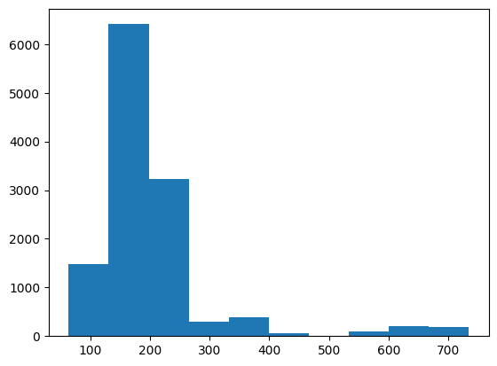

```python
# Par exemple, tracé de l'histograme des valeurs "LowQ" sur l'ensemble des données:
plt.hist(prices_pd["LowQ"])
```

**[Q]** **Estimation de densité**

Nous allons maintenant nous intéresser au calcul du nombre d'états concernés par une fourchette de prix. Pour cela:

- Calculer le tableau des prix moyens de la facon suivante

```python
prix_moyens=prices_pd[["State","LowQ"]].groupby(["State"]).mean()
#print(prix_moyens)
#print("===========")
prix_moyens=prix_moyens.values.ravel()

prix_moyens
```

```
array([146.83260331, 387.23272727, 190.8268595 , 127.34545455,
       190.79599174, 226.79061983, 253.02487603, 205.04599174,
       210.56355372, 153.2053719 , 150.26409091, 167.09384298,
       139.96285124, 186.54516529, 158.93165289, 248.59553719,
       120.1992562 , 124.1568595 , 146.77698347, 244.95165289,
       190.18508264, 220.07      , 252.64491736, 182.68330579,
       142.75194215, 147.50859504, 659.85107438, 137.89590909,
       241.79293388, 639.80780992, 228.61177686,  80.89095041,
       201.34      , 150.81061983, 333.96822314, 165.1696281 ,
       119.89392562, 170.17338843, 193.22975207, 203.00066116,
       184.46760331, 124.31801653, 190.12157025, 143.36289256,
       193.84429752, 189.6007438 , 224.23900826, 143.18338843,
       155.71516529, 239.56508264, 161.3       ])
```

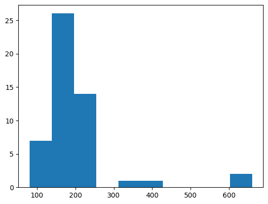

```python
# Histogramme:
plt.hist(prix_moyens)
plt.show()
```

**[Q]** **Bornes de variations**

- Calculer les valeurs min et max des prix moyens

**[Q]** **Calcul d'un effectif**

Pour mieux contrôler le tracé de l'histogramme, il est préférable de donner la taille de l'intervalle de discrétisation à utiliser pour calculer les effectifs.

En utilisant l'option bins de la fonction de matplotlib `hist`, tracer l'histogramme avec un intervalle de discrétisation de taille 20.

**[Q]** **Changement d'échelle**

Même chose mais avec maintenant un intervalle de taille 40.

### Variance

**[Q]** **Calcul de variances**

On souhaite maintenant rajouter une colonne `HighQ_var` aux données originales contenant la variance des prix par état. Donner les intructions Python correspondantes.

**ATTENTION**, cela suppose de traiter les états (State) les uns après les autres... par exemple, à l'aide d'un `groupby` sur le dataframe...

Remarque: pour être efficace, utiliser la fonction variance de pandas pour les dataframes...

# Travail de synthèse : La Californie

Pandas permet de faire la synthèse de données de la manière suivante (pour le DataFrame de nom `df`):

```
df.describe()
```

**[Q]** Vérifier que les valeurs trouvées sur l'état de la Californie correspondent aux valeurs trouvées grâce à vos différentes fonctions.

Pour cela, donner dans ce qui suit le code qui utilise vos fonctions (moyennes, variance, et quartiles) ainsi que le résutlats de la fonction `describe`.

**[Q]** **Matrice de corrélation**

Nous allons maintenant nous intéresser à calculer la corrélation entre les prix à New York et les prix en Californie.

Commencer par représenter le nuage des points des prix (par date) en Californie (axe $X$) et à New York (axe $Y$) pour la bonne qualité.

Pour cela, on commence par créer un DataFrame avec ces informations:

```python
prix_ny=prices_pd[prices_pd['State']=='New York']
prix_ca=prices_pd[prices_pd['State']=='California']
prix_ca_ny=prix_ca.merge(prix_ny,on='date')
prix_ca_ny.head()

# Exécuter cette boîte et commenter le résultat obtenu
```

**[Q]** **Nuages de points**

Représenter graphiquement le nuage des points : voir http://matplotlib.org/examples/shapes_and_collections/scatter_demo.html

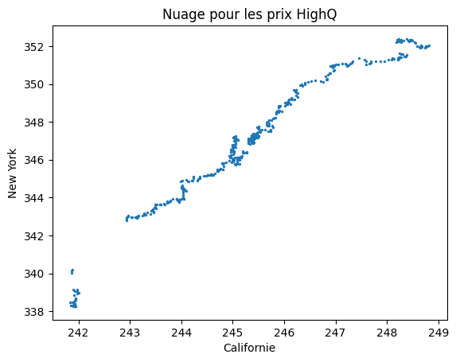

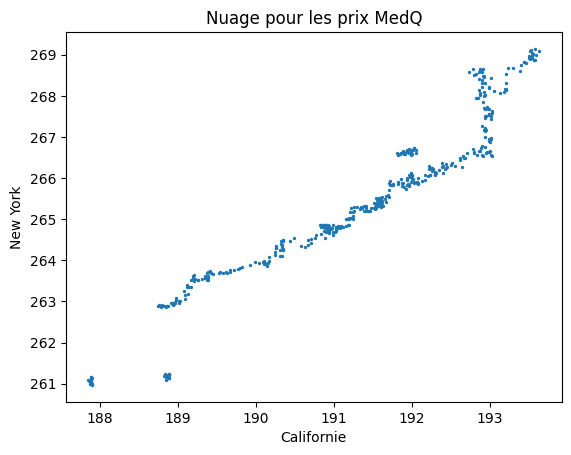

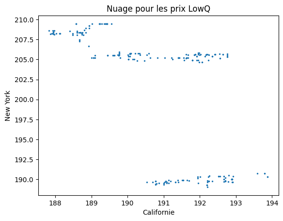

**[Q]** **Corrélations**

A l'aide de la fonction `moyenne` écrite précédemment, écrire une fonction `correlation(X,Y)` qui calcule la corrélation lineaire entre deux variables $X$ et $Y$ fournis sous la forme de deux tableaux Numpy.

Remarque: coefficient de corrélation linéaire de deux variables $X$ et $Y$ (on choisit le coefficient de Pearson): $$c = \frac{cov(X,Y)}{\sigma_X \sigma_Y}$$

avec les définitions suivantes:

- $cov(X,Y)= \frac{1}{n}\sum_{i=1}^{n} (x_i-\bar{X})(y_i-\bar{Y})$: mesure de covariance entre $X$ et $Y$ qui contiennent chacune $n$ valeurs, et de moyenne $\bar{X}$ et $\bar{Y}$ respectivement.
- $\sigma_X = \sqrt{\frac{1}{n}\sum_{i=1}^{n}(x_i - \bar{X})^2}$: écart-type de la variable $X$ (resp. $\sigma_Y$ pour la variable $Y$).

**Remarque 2: il ne doit pas y avoir de boucle (for, while, compréhension) dans votre fonction...**

```python
# Appliquer votre fonction avec l'instruction suivante:

print("Correlation de HighQ_x et HighQ_y : %f"%correlation(prix_ca_ny["HighQ_x"].values,prix_ca_ny["HighQ_y"].values))
```

```
Affichage des valeurs intermédiaire pour tester :
	Covariance:  5.903637205668625
	Ecart-type pour X:  1.725121252002434
	Ecart-type pour Y:  3.4954077335603095
Correlation de HighQ_x et HighQ_y : 0.979044
```

**[Q]** Compléter la ligne suivante pour obtenir le résultat fourni par la fonction pandas `corr`.

```python
# A COMPLETER :
#prix_ca_ny[["HighQ_x","HighQ_y"]].#COMPLETER ICI#
```

|  | HighQ_x | HighQ_y |
| --- | --- | --- |
| HighQ_x | 1.000000 | 0.979044 |
| HighQ_y | 0.979044 | 1.000000 |

**[Q]** **Matrice de corrélations**

Calculer la matrice des corrélations pour toutes les combinaisons d'états.

|  | HighQ_x | HighQN_x | MedQ_x | MedQN_x | LowQ_x | LowQN_x | HighQ_y | HighQN_y | MedQ_y | MedQN_y | LowQ_y | LowQN_y |
| --- | --- | --- | --- | --- | --- | --- | --- | --- | --- | --- | --- | --- |
| HighQ_x | 1.000000 | -0.982854 | 0.946719 | -0.980028 | 0.782783 | -0.984319 | 0.979044 | -0.976668 | 0.989382 | -0.977453 | -0.932566 | -0.974094 |
| HighQN_x | -0.982854 | 1.000000 | -0.973784 | 0.999186 | -0.895365 | 0.999122 | -0.987104 | 0.998151 | -0.993179 | 0.998514 | 0.873900 | 0.997927 |
| MedQ_x | 0.946719 | -0.973784 | 1.000000 | -0.979122 | 0.820507 | -0.975646 | 0.957568 | -0.978808 | 0.963848 | -0.979311 | -0.797989 | -0.976565 |
| MedQN_x | -0.980028 | 0.999186 | -0.979122 | 1.000000 | -0.895556 | 0.999201 | -0.987791 | 0.999322 | -0.992846 | 0.999693 | 0.875562 | 0.998666 |
| LowQ_x | 0.782783 | -0.895365 | 0.820507 | -0.895556 | 1.000000 | -0.897104 | 0.882252 | -0.894950 | 0.803564 | -0.897553 | -0.640802 | -0.894443 |
| LowQN_x | -0.984319 | 0.999122 | -0.975646 | 0.999201 | -0.897104 | 1.000000 | -0.989216 | 0.997727 | -0.992864 | 0.998349 | 0.871484 | 0.996971 |
| HighQ_y | 0.979044 | -0.987104 | 0.957568 | -0.987791 | 0.882252 | -0.989216 | 1.000000 | -0.988137 | 0.984437 | -0.988077 | -0.869366 | -0.984466 |
| HighQN_y | -0.976668 | 0.998151 | -0.978808 | 0.999322 | -0.894950 | 0.997727 | -0.988137 | 1.000000 | -0.992520 | 0.999836 | 0.869745 | 0.999008 |
| MedQ_y | 0.989382 | -0.993179 | 0.963848 | -0.992846 | 0.803564 | -0.992864 | 0.984437 | -0.992520 | 1.000000 | -0.992488 | -0.925460 | -0.990890 |
| MedQN_y | -0.977453 | 0.998514 | -0.979311 | 0.999693 | -0.897553 | 0.998349 | -0.988077 | 0.999836 | -0.992488 | 1.000000 | 0.869437 | 0.998971 |
| LowQ_y | -0.932566 | 0.873900 | -0.797989 | 0.875562 | -0.640802 | 0.871484 | -0.869366 | 0.869745 | -0.925460 | 0.869437 | 1.000000 | 0.868748 |
| LowQN_y | -0.974094 | 0.997927 | -0.976565 | 0.998666 | -0.894443 | 0.996971 | -0.984466 | 0.999008 | -0.990890 | 0.998971 | 0.868748 | 1.000000 |

**[Q]** **D'autres corrélations...**

Calculer les correlations entre le prix (`low` et `high`) en fonction du revenu moyen par état disponible dans le tableau `demography_pd` chargé au début de cette feuille Jupyter.

Que peut-on en conclure ?